# 第八章 随机森林模型

#### 8.2.2.2 生成简单衍生变量

```python
df['close-open'] = (df['close'] - df['open'])/df['open']
df['high-low'] = (df['high'] - df['low'])/df['low']

df['pre_close'] = df['close'].shift(1)  # 该列所有往下移一行形成昨日收盘价
df['price_change'] = df['close']-df['pre_close']
df['p_change'] = (df['close']-df['pre_close'])/df['pre_close']*100

df.head()
```

|  | ts_code | trade_date | open | high | low | close | pre_close | change | pct_chg | vol | amount | close-open | high-low | price_change | p_change |
| --- | --- | --- | --- | --- | --- | --- | --- | --- | --- | --- | --- | --- | --- | --- | --- |
| 1083 | 000002.SZ | 20150105 | 14.39 | 15.29 | 14.22 | 14.91 | NaN | 1.01 | 7.27 | 6560835.70 | 9.700712e+06 | 0.036136 | 0.075246 | NaN | NaN |
| 1082 | 000002.SZ | 20150106 | 14.60 | 14.99 | 14.05 | 14.36 | 14.91 | -0.55 | -3.69 | 3346346.83 | 4.839616e+06 | -0.016438 | 0.066904 | -0.55 | -3.688799 |
| 1081 | 000002.SZ | 20150107 | 14.26 | 14.50 | 14.00 | 14.23 | 14.36 | -0.13 | -0.91 | 2642051.33 | 3.772151e+06 | -0.002104 | 0.035714 | -0.13 | -0.905292 |
| 1080 | 000002.SZ | 20150108 | 14.32 | 14.37 | 13.46 | 13.59 | 14.23 | -0.64 | -4.50 | 2639394.18 | 3.629554e+06 | -0.050978 | 0.067608 | -0.64 | -4.497540 |
| 1079 | 000002.SZ | 20150109 | 13.54 | 14.22 | 13.29 | 13.45 | 13.59 | -0.14 | -1.03 | 3294584.30 | 4.521978e+06 | -0.006647 | 0.069977 | -0.14 | -1.030169 |

#### 8.2.2.3 生成移动平均线指标MA值

```python
df['MA5'] = df['close'].rolling(5).mean()
df['MA10'] = df['close'].rolling(10).mean()

df.head(15)  # head(15)表示展示前15行，因为要展示10行以上，才能看到MA10有值
```

|  | ts_code | trade_date | open | high | low | close | pre_close | change | pct_chg | vol | amount | close-open | high-low | price_change | p_change | MA5 | MA10 |
| --- | --- | --- | --- | --- | --- | --- | --- | --- | --- | --- | --- | --- | --- | --- | --- | --- | --- |
| 1083 | 000002.SZ | 20150105 | 14.39 | 15.29 | 14.22 | 14.91 | NaN | 1.01 | 7.27 | 6560835.70 | 9.700712e+06 | 0.036136 | 0.075246 | NaN | NaN | NaN | NaN |
| 1082 | 000002.SZ | 20150106 | 14.60 | 14.99 | 14.05 | 14.36 | 14.91 | -0.55 | -3.69 | 3346346.83 | 4.839616e+06 | -0.016438 | 0.066904 | -0.55 | -3.688799 | NaN | NaN |
| 1081 | 000002.SZ | 20150107 | 14.26 | 14.50 | 14.00 | 14.23 | 14.36 | -0.13 | -0.91 | 2642051.33 | 3.772151e+06 | -0.002104 | 0.035714 | -0.13 | -0.905292 | NaN | NaN |
| 1080 | 000002.SZ | 20150108 | 14.32 | 14.37 | 13.46 | 13.59 | 14.23 | -0.64 | -4.50 | 2639394.18 | 3.629554e+06 | -0.050978 | 0.067608 | -0.64 | -4.497540 | NaN | NaN |
| 1079 | 000002.SZ | 20150109 | 13.54 | 14.22 | 13.29 | 13.45 | 13.59 | -0.14 | -1.03 | 3294584.30 | 4.521978e+06 | -0.006647 | 0.069977 | -0.14 | -1.030169 | 14.108 | NaN |
| 1078 | 000002.SZ | 20150112 | 13.32 | 13.32 | 12.75 | 13.12 | 13.45 | -0.33 | -2.45 | 2436341.36 | 3.180963e+06 | -0.015015 | 0.044706 | -0.33 | -2.453532 | 13.750 | NaN |
| 1077 | 000002.SZ | 20150113 | 13.05 | 13.38 | 12.97 | 13.07 | 13.12 | -0.05 | -0.38 | 1664610.33 | 2.187988e+06 | 0.001533 | 0.031611 | -0.05 | -0.381098 | 13.492 | NaN |
| 1076 | 000002.SZ | 20150114 | 13.07 | 13.30 | 12.87 | 13.10 | 13.07 | 0.03 | 0.23 | 1646818.02 | 2.160268e+06 | 0.002295 | 0.033411 | 0.03 | 0.229533 | 13.266 | NaN |
| 1075 | 000002.SZ | 20150115 | 13.13 | 13.83 | 13.00 | 13.77 | 13.10 | 0.67 | 5.11 | 2429686.64 | 3.265536e+06 | 0.048743 | 0.063846 | 0.67 | 5.114504 | 13.302 | NaN |
| 1074 | 000002.SZ | 20150116 | 13.77 | 13.77 | 13.39 | 13.52 | 13.77 | -0.25 | -1.82 | 2129475.97 | 2.892247e+06 | -0.018155 | 0.028379 | -0.25 | -1.815541 | 13.316 | 13.712 |
| 1073 | 000002.SZ | 20150119 | 12.50 | 12.90 | 12.17 | 12.17 | 13.52 | -1.35 | -9.99 | 3603625.65 | 4.483885e+06 | -0.026400 | 0.059984 | -1.35 | -9.985207 | 13.126 | 13.438 |
| 1072 | 000002.SZ | 20150120 | 12.20 | 12.60 | 12.06 | 12.35 | 12.17 | 0.18 | 1.48 | 2914688.79 | 3.604938e+06 | 0.012295 | 0.044776 | 0.18 | 1.479047 | 12.982 | 13.237 |
| 1071 | 000002.SZ | 20150121 | 12.33 | 13.20 | 12.10 | 13.05 | 12.35 | 0.70 | 5.67 | 3555294.15 | 4.554004e+06 | 0.058394 | 0.090909 | 0.70 | 5.668016 | 12.972 | 13.119 |
| 1070 | 000002.SZ | 20150122 | 13.02 | 13.65 | 12.92 | 13.58 | 13.05 | 0.53 | 4.06 | 3224727.24 | 4.326298e+06 | 0.043011 | 0.056502 | 0.53 | 4.061303 | 12.934 | 13.118 |
| 1069 | 000002.SZ | 20150123 | 13.57 | 14.09 | 13.30 | 13.92 | 13.58 | 0.34 | 2.50 | 3310408.58 | 4.561752e+06 | 0.025792 | 0.059398 | 0.34 | 2.503682 | 13.014 | 13.165 |

```python
# 删除空值
df.dropna(inplace=True)  # 删除空值行，也可以写成df = df.dropna()
df.head(5)
```

|  | ts_code | trade_date | open | high | low | close | pre_close | change | pct_chg | vol | amount | close-open | high-low | price_change | p_change | MA5 | MA10 |
| --- | --- | --- | --- | --- | --- | --- | --- | --- | --- | --- | --- | --- | --- | --- | --- | --- | --- |
| 1074 | 000002.SZ | 20150116 | 13.77 | 13.77 | 13.39 | 13.52 | 13.77 | -0.25 | -1.82 | 2129475.97 | 2.892247e+06 | -0.018155 | 0.028379 | -0.25 | -1.815541 | 13.316 | 13.712 |
| 1073 | 000002.SZ | 20150119 | 12.50 | 12.90 | 12.17 | 12.17 | 13.52 | -1.35 | -9.99 | 3603625.65 | 4.483885e+06 | -0.026400 | 0.059984 | -1.35 | -9.985207 | 13.126 | 13.438 |
| 1072 | 000002.SZ | 20150120 | 12.20 | 12.60 | 12.06 | 12.35 | 12.17 | 0.18 | 1.48 | 2914688.79 | 3.604938e+06 | 0.012295 | 0.044776 | 0.18 | 1.479047 | 12.982 | 13.237 |
| 1071 | 000002.SZ | 20150121 | 12.33 | 13.20 | 12.10 | 13.05 | 12.35 | 0.70 | 5.67 | 3555294.15 | 4.554004e+06 | 0.058394 | 0.090909 | 0.70 | 5.668016 | 12.972 | 13.119 |
| 1070 | 000002.SZ | 20150122 | 13.02 | 13.65 | 12.92 | 13.58 | 13.05 | 0.53 | 4.06 | 3224727.24 | 4.326298e+06 | 0.043011 | 0.056502 | 0.53 | 4.061303 | 12.934 | 13.118 |

#### 8.2.2.5 用Ta-Lib库生成相对强弱指标的RSI值

RSI

- RSI值能反映短期内股票涨势相对于跌势的强弱, 帮助判断股价的涨跌趋势, RSI值越大, 涨势相对于跌势更强, 反之则涨势相对于跌势越弱, 计算公式为 $$ RSI = \frac{N日平均上涨价格}{N日平均上涨价格 + N日平均下跌价格} \times 100 (\%) $$ 一般$N$的取值为6、12、24
- 通常情况下RSI值位于20~80之间, 超过80则为超买状态 (股票买方处于非常强势的地位), 低于20则为超卖状态, 等于50则认为买卖双方力量均等

```python
import talib

df["RSI"] = talib.RSI(df['close'], timeperiod=12)
```

#### 8.2.2.6 用TA-Lib库生成动量指标MOM值

MOM

- MOM是momentum (动量) 的缩写, 反映了一段时期内股价的涨跌速度, 计算公式为 $$MOM = C - C_n$$ 其中$C$表示当前的收盘价, $C_n$ 表示$n$天前的收盘价

```python
df['MOM'] = talib.MOM(df['close'], timeperiod=5)
```

#### 8.2.2.7 用TA-Lib库生成指数移动平均值EMA

EMA

- 以指数式递减加权的移动平均, 并根据计算结果进行分析, 用于判断股价未来走势的变动趋势
- 与移动平均线指标MA值优点类似, 不过计算公式更复杂
- 计算公式为 $$EMA_{today} = \alpha Price_{today} + (1 - \alpha)EMA_{yesterday}$$ 其中$EMA_{today}$为当天的EMA值; $Price_{today}$为当天的收盘价; $EMA_{yesterday}$为昨天的EMA值; $\alpha$为平滑指数, 一般取 $\frac{2}{N+1}$, $N$表示天数, 当$N$为6时, $\alpha$为$\frac{2}{7}$, 对应的EMA称为EMA6, 即6日指数移动平均值

  公式不断递归, 直到第1个EMA值出现 (第一个EMA通常为开头五个数的均值)
- 比如

  取第1个EMA值为开头5个数的均值, 故前5天都没有EMA值; 6号的EMA值就是第1个EMA值, 为前5天的均值, 即1; 7号的EMA值为第2个EMA值, 计算过程为 $$EMA_{today} = \frac{2}{7} \times 2 + (1 - \frac{2}{7}) \times EMA_{yesterday} = \frac{2}{7} \times 2 + (1 - \frac{2}{7}) \times 1 = \frac{9}{7} \approx 1.2857$$
- 对于EMA值而言, 近期的股价比之前更久远的股价更重要(在其计算公式中, 近期股价的权重更大), 不像MA值那样一视同仁
- EMA12称为快的指数移动平均线, EMA26称为慢的指数移动平均线

```python
df['EMA12'] = talib.EMA(df['close'], timeperiod=12)  # 12日指数移动平均线
df['EMA26'] = talib.EMA(df['close'], timeperiod=26)  # 26日指数移动平均线
```

#### 8.2.2.8 用TA-Lib库生成异同移动平均线MACD值

- MACD是股票市场上的常用指标, 它是基于EMA值的衍生变量, 计算方法比较复杂
- 一种趋势类指标, 其变化代表着市场趋势的变化, 不同K线级别的MACD代表当前级别周期中的买卖趋势
- MACD是从双指数移动平均值发展而来的, 计算步骤为
  - 计算EMA12和EMA26
  - 由快的指数移动平均线EMA12减去慢的指数移动平均线EMA26得到`DIF`值

    `DIF = EMA12 - EMA26`, 反映的是两条移动平均线的差值, DIF值对应的连线也称为`快速线`

    DEA值是DIF的9日加权移动均线值, 计算方法类似EMA9, 区别就是计算EMA9用的是收盘价, 而计算DEA值用的是DIF值

    DEA值对应的连线也称为`慢速线`
  - 再用2 × (DIF值 - DIF值的9日加权移动均线DEA值) 得到MACD值

    `MCAD = 2 × (DIF - DEA)`, 也被称为MACD柱

    因此MACD技术指标图是由两线一柱组合而成的, 快速线是DIF值, 慢速线是DEA值, 柱形图为MACD值

### 8.2.3 多因子模型搭建

- 本案例中的模型是根据多个特征进行搭建的, 在量化金融领域称为多因子模型
- 股票数据是时间序列数据

#### 8.2.3.1 引入需要用到的库

```python
import tushare as ts  # 股票基本数据相关库
import numpy as np  # 科学计算相关库
import pandas as pd  # 科学计算相关库
import talib  # 股票衍生变量数据相关库
import matplotlib.pyplot as plt  # 引入绘图相关库
from sklearn.ensemble import RandomForestClassifier  # 引入分类决策树模型
from sklearn.metrics import accuracy_score  # 引入准确度评分函数
import warnings
warnings.filterwarnings("ignore") # 忽略警告信息，警告非报错，不影响代码执行
```

#### 8.2.3.2 获取数据

```python
# 准备查询参数
stock_code = '000002.SZ'  # 股票代码，注意要加上后缀.SZ 表示深交所股票
start_date = '20150101'
end_date = '20191231'

pro = ts.pro_api()

pro = ts.pro_api(token)

df = pro.daily(ts_code=stock_code, start_date=start_date, end_date=end_date) #如果不写开始日期和结束日期, 会默认获取当天往前3年的数据

df['date'] = df['trade_date']

df = df.set_index('date')  # 设置日期为索引

df.sort_values(by='date', ascending=True, inplace=True)

df.head(5)
```

| date | ts_code | trade_date | open | high | low | close | pre_close | change | pct_chg | vol | amount |
| --- | --- | --- | --- | --- | --- | --- | --- | --- | --- | --- | --- |
| 20150105 | 000002.SZ | 20150105 | 14.39 | 15.29 | 14.22 | 14.91 | 13.90 | 1.01 | 7.27 | 6560835.70 | 9.700712e+06 |
| 20150106 | 000002.SZ | 20150106 | 14.60 | 14.99 | 14.05 | 14.36 | 14.91 | -0.55 | -3.69 | 3346346.83 | 4.839616e+06 |
| 20150107 | 000002.SZ | 20150107 | 14.26 | 14.50 | 14.00 | 14.23 | 14.36 | -0.13 | -0.91 | 2642051.33 | 3.772151e+06 |
| 20150108 | 000002.SZ | 20150108 | 14.32 | 14.37 | 13.46 | 13.59 | 14.23 | -0.64 | -4.50 | 2639394.18 | 3.629554e+06 |
| 20150109 | 000002.SZ | 20150109 | 13.54 | 14.22 | 13.29 | 13.45 | 13.59 | -0.14 | -1.03 | 3294584.30 | 4.521978e+06 |

```python
# 简单衍生变量构造
df['close-open'] = (df['close'] - df['open'])/df['open']
df['high-low'] = (df['high'] - df['low'])/df['low']

df['pre_close'] = df['close'].shift(1)  # 该列所有往下移一行形成昨日收盘价
df['price_change'] = df['close']-df['pre_close']
df['p_change'] = (df['close']-df['pre_close'])/df['pre_close']*100

# 移动平均线相关数据构造
df['MA5'] = df['close'].rolling(5).mean()
df['MA10'] = df['close'].rolling(10).mean()
df.dropna(inplace=True)  # 删除空值

# 通过Ta_lib库构造衍生变量
df['RSI'] = talib.RSI(df['close'], timeperiod=12)  # 相对强弱指标
df['MOM'] = talib.MOM(df['close'], timeperiod=5)  # 动量指标
df['EMA12'] = talib.EMA(df['close'], timeperiod=12)  # 12日指数移动平均线
df['EMA26'] = talib.EMA(df['close'], timeperiod=26)  # 26日指数移动平均线
df['MACD'], df['MACDsignal'], df['MACDhist'] = talib.MACD(df['close'], fastperiod=12, slowperiod=26, signalperiod=9)  # MACD值
df.dropna(inplace=True)  # 删除空值
```

```python
print(df.tail(5))

df['volume'] = df['vol']

print(df.columns)
```

```
            ts_code trade_date   open   high    low  close  pre_close  change  \
date
20191225  000002.SZ   20191225  30.40  30.63  30.18  30.29      30.38   -0.09
20191226  000002.SZ   20191226  30.50  31.30  30.50  31.12      30.29    0.83
20191227  000002.SZ   20191227  31.23  31.32  30.81  31.00      31.12   -0.12
20191230  000002.SZ   20191230  31.35  31.79  31.02  31.57      31.00    0.57
20191231  000002.SZ   20191231  31.35  32.45  31.32  32.18      31.57    0.61

          pct_chg        vol  ...  p_change     MA5    MA10        RSI   MOM  \
date                          ...
20191225  -0.2962  685037.32  ... -0.296248  30.878  30.075  63.075563 -0.02
20191226   2.7402  888790.74  ...  2.740178  30.896  30.387  68.890164  0.09
20191227  -0.3856  703096.48  ... -0.385604  30.760  30.672  67.220611 -0.68
20191230   1.8387  915751.42  ...  1.838710  30.872  30.884  70.877814  0.56
20191231   1.9322  663497.98  ...  1.932214  31.232  31.057  74.233951  1.80

              EMA12      EMA26      MACD  MACDsignal  MACDhist
date
20191225  29.908556  28.973211  0.935345    0.772958  0.162387
20191226  30.094932  29.132233  0.962699    0.810906  0.151793
20191227  30.234173  29.270586  0.963587    0.841442  0.122145
20191230  30.439685  29.440913  0.998772    0.872908  0.125864
20191231  30.707426  29.643808  1.063618    0.911050  0.152567

[5 rows x 24 columns]
Index(['ts_code', 'trade_date', 'open', 'high', 'low', 'close', 'pre_close',
       'change', 'pct_chg', 'vol', 'amount', 'close-open', 'high-low',
       'price_change', 'p_change', 'MA5', 'MA10', 'RSI', 'MOM', 'EMA12',
       'EMA26', 'MACD', 'MACDsignal', 'MACDhist', 'volume'],
      dtype='object')
```

#### 8.2.3.3 提取特征变量和目标变量

```python
X = df[['close', 'volume', 'close-open', 'MA5', 'MA10', 'high-low', 'RSI', 'MOM', 'EMA12', 'MACD', 'MACDsignal', 'MACDhist']]
y = np.where(df['price_change'].shift(-1)> 0, 1, -1) #
```

首先强调最核心的一点：应该是今天的股价信息预测下一天的股价涨跌情况，所以y应该是下一天的股价变化情况

其中Numpy库中的where()函数的使用方法如下所示： np.where(判断条件,满足条件的赋值,不满足条件的赋值)

其中df['price_change'].shift(-1)则是利用shift()函数将price_change（股价变化）这一列往上移动一行，这样就获得了每一行对应的下一天股价涨跌情况。

因此这里的判断条件就是下一天股价是否大于0，如果下一天股价涨了的我们则y赋值为数字1，下一天股价跌了的，则y赋值为数字-1。这个下一天的股价涨跌情况就是我们根据当天股票基本数据以及衍生变量预测的内容。

#### 8.2.3.4 划分训练集和测试集

训练集与测试集的划分要按照时间序列划分，而不是像之前利用train_test_split()函数进行划分。原因在于股票价格的变化趋势具有时间性，如果我们随机划分，则会破坏时间性特征，因为我们是根据当天数据来预测下一天的股价涨跌情况，而不是任意一天的股票数据来预测下一天的股价涨跌情况。

因此，将前90%的数据作为训练集，后10%的数据作为测试集

```python
X_length = X.shape[0]  # shape属性获取X的行数和列数，shape[0]即表示行数
split = int(X_length * 0.9)

X_train, X_test = X[:split], X[split:]
y_train, y_test = y[:split], y[split:]
```

#### 8.2.3.5 模型搭建

```python
model = RandomForestClassifier(max_depth=3, n_estimators=10, min_samples_leaf=10, random_state=1) #max_depth=3设置决策树的最大深度为3, 即每个决策树最多只有3层; n_estimators=10设置弱学习器的个数为10, 即该随机森林中共有10个决策树; min_samples_leaf=10设置叶子节点的最小样本数为10, 即如果叶子节点的样本数小于10则停止分裂
model.fit(X_train, y_train)
```

```
RandomForestClassifier(max_depth=3, min_samples_leaf=10, n_estimators=10,
                       random_state=1)
```

### 8.2.4 模型使用与评估

#### 8.2.4.1 预测下一天的股价涨跌情况

```python
y_pred = model.predict(X_test)
print(y_pred)
```

```
[-1 -1 -1 -1  1 -1 -1 -1  1 -1  1  1 -1  1 -1 -1 -1  1  1 -1 -1 -1  1  1
 -1  1 -1  1 -1 -1 -1  1 -1  1  1 -1  1 -1  1  1 -1 -1  1 -1 -1 -1  1 -1
 -1  1 -1 -1  1 -1  1  1 -1 -1 -1  1 -1  1 -1 -1 -1  1 -1 -1  1 -1 -1 -1
 -1 -1 -1 -1 -1 -1 -1 -1 -1  1  1 -1 -1 -1  1 -1 -1  1 -1 -1 -1 -1 -1 -1
 -1 -1 -1 -1 -1 -1 -1 -1 -1]
```

```python
a = pd.DataFrame()  # 创建一个空DataFrame
a['预测值'] = list(y_pred)
a['实际值'] = list(y_test)
print(a.head())
```

```
   预测值  实际值
0   -1   -1
1   -1   -1
2   -1   -1
3   -1   -1
4    1    1
```

```python
y_pred_proba = model.predict_proba(X_test)

y_pred_proba = pd.DataFrame(y_pred_proba, columns=['预测为-1的概率', '预测为1的概率'])#-1表示下一天股价不变或下跌, 1表示下一天股价上涨

print(y_pred_proba)
```

```
     预测为-1的概率   预测为1的概率
0    0.565460  0.434540
1    0.505614  0.494386
2    0.528330  0.471670
3    0.528330  0.471670
4    0.480140  0.519860
..        ...       ...
100  0.565460  0.434540
101  0.565460  0.434540
102  0.528510  0.471490
103  0.587631  0.412369
104  0.596026  0.403974

[105 rows x 2 columns]
```

#### 8.2.4.2 模型准确度评估

```python
from sklearn.metrics import accuracy_score
score = accuracy_score(y_pred, y_test)
print(score)

model.score(X_test, y_test)
```

```
0.5428571428571428
```

```
0.5428571428571428
```

#### 8.2.4.3 分析特征变量的特征重要性

```python
# 通过如下代码可以更好的展示特征及其特征重要性：
features = X.columns
importances = model.feature_importances_
a = pd.DataFrame()
a['特征'] = features
a['特征重要性'] = importances
a = a.sort_values('特征重要性', ascending=False)
print(a)
```

```
            特征     特征重要性
7          MOM  0.177669
0        close  0.149504
10  MACDsignal  0.110953
5     high-low  0.104257
1       volume  0.096303
4         MA10  0.088574
2   close-open  0.078953
3          MA5  0.069882
9         MACD  0.066631
11    MACDhist  0.033678
8        EMA12  0.019082
6          RSI  0.004513
```

### 8.2.5 参数调优

```python
from sklearn.model_selection import GridSearchCV  # 网格搜索合适的超参数
# 指定分类器中参数的范围
parameters = {'n_estimators':[5, 10, 20], 'max_depth':[2, 3, 4, 5], 'min_samples_leaf':[5, 10, 20, 30]}
new_model = RandomForestClassifier(random_state=1)  # 构建分类器
grid_search = GridSearchCV(new_model, parameters, cv=6, scoring='accuracy')  # cv=6表示交叉验证6次，scoring='roc_auc'表示以ROC曲线的AUC评分作为模型评价准则, 默认为'accuracy', 即按准确度评分
```

```python
grid_search.fit(X_train, y_train)  # 传入数据
grid_search.best_params_  # 输出参数的最优值
```

```
{'max_depth': 3, 'min_samples_leaf': 30, 'n_estimators': 10}
```

### 8.2.6 收益回测曲线绘制

- 相比于模型的预测准确度, 在商业实战中, 更关心收益回测曲线, 也就是看根据搭建的模型获得的结果是否比不利用模型获得的结果更好
- 根据当天的股价预测数据预测下一天的股价涨跌情况, 如果预测为1, 则在下一天买入, 否则卖出, 所以这里通过shift(1)将预测结果这一列向下移动一行, 这样才能和下一天的股价变化率相匹配, 再用cumprod()函数来计算收益率

```python
X_test['prediction'] = model.predict(X_test)
X_test['p_change'] = (X_test['close'] - X_test['close'].shift(1)) / X_test['close'].shift(1)

X_test['origin'] = (X_test['p_change'] + 1).cumprod()
X_test['strategy'] = (X_test['prediction'].shift(1) * X_test['p_change'] + 1).cumprod()

print(X_test[['strategy', 'origin']].tail())
```

```
          strategy    origin
date
20191225  1.113699  1.015761
20191226  1.083182  1.043595
20191227  1.087359  1.039571
20191230  1.067365  1.058685
20191231  1.046741  1.079142
```

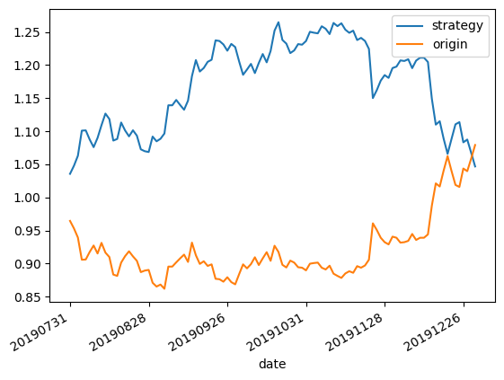

```python
# 通过如下代码将收益情况删除空值后可视化，并设置X轴刻度自动倾斜：
X_test[['strategy', 'origin']].dropna().plot()
plt.gcf().autofmt_xdate()
plt.show()
```